# Analyze XP_028889033 family evolution and adhesin properties

Bin He

2022-06-12 (updated 2022-08-21)

# Goal

Analyze the adhesin properties of the Hyr/Iff-like (Hil) family in the Sacchromycetes This is version 4 of the analysis, using the expanded blast hits on 2022-05

# Adhesin predictions

The goal of the first analysis is to assess the evidence for each Hil family member as encoding yeast adhesins. We rely on a ML-based prediction algorithm and the following known sequence features of adhesins: signal peptide + GPI-anchor, tandem repeats, high S/T frequency (possibly glycosylation)

## Basic information

First get the basic information about the sequences in this study.

```r
#sps.list <- c("Cduobushaemulonis","Cpseudohaemulonis","Chaemuloni","Cauris","Clusitaniae","Dhansenii","Cparapsilosis","Lelongisporus","Ctropicalis","Cdubliniensis","Calbicans","Sstipitis","Klactis","Ncastellii","Cglabrata","Nbracarensis","Ndelphensis","Nnivariensis")
blastInfo <- read_tsv("../data/expanded-blast-homologs-info.tsv", col_types = cols())# %>%
#  mutate(species_id = factor(species, levels = sps.list), species = NULL)
```

## ML adhesin predictions

[FungalRV](http://fungalrv.igib.res.in/) is a Support Vector Machine (SVM) based prediction algorithms that use sequence features such as amino acid composition (frequency, physiochemical properties etc.) as input and train Machine Learning models to distinguish fungal adhesins from non-adhesins.

```r
frv.th = 0.511 # recommended FungalRV score threshold
frv <- read_tsv("../output/FungalRV/fungalRV-results.txt", skip = 3, col_names = c("name","frv.score"), col_types = "cd") %>%
  mutate(name = str_sub(name, 2), frv.pred = frv.score > frv.th)
#if("frv.score" %in% names(seqInfo))
#  seqInfo <- select(seqInfo, -frv.score, -frv.pred, -faa.score, -faa.pred)
#seqInfo <- seqInfo %>% left_join(frv) %>% left_join(faa)
```

## SP and GPI-anchor prediction

GPI-anchored proteins are characterized by an N-terminal signal peptide, which would direct the protein to the secretary pathway, and a C-terminal GPI-anchor peptide, which would be cleaved and replaced by the GPI-anchor, allowing the protein to be tethered to the cell wall.

For signal peptide, I used the [SignalP server](https://services.healthtech.dtu.dk/service.php?SignalP). Its latest version is 6.0.

```r
# Signal peptide
gff.names <- c("name", "source", "type", "start", "end", "prob", "na1", "na2", "na3")
signalp6 <- read_tsv("../output/web-download/signalp_6.0_result.gff3", comment = "#", col_names = gff.names, col_types = "ccciidccc")

#if("signalp" %in% names(seqInfo))
#  seqInfo <- select(seqInfo, -signalp)
#
#seqInfo <- left_join(seqInfo, select(signalp5, name = id, prob), by = c("name" = "name")) %>%
#  mutate(signalp = !is.na(prob)) %>% select(-prob)
```

For GPI-anchor prediction, I used the [PredGPI server](http://gpcr.biocomp.unibo.it/predgpi/).

```r
tmp <- read_delim("../output/web-download/predgpi-result-headline-only.txt", delim = "|", col_names = c("name","fp","omega"))
pred.gpi <- tmp %>%
  mutate(name = str_sub(name,2,-2), # remove > and the trailing space
         fp = as.numeric(str_sub(fp, 9, -2)), # extract the numeric part
         gpi.pred = fp <= 0.01,    # based on the cutoff of the PredGPI server (prob < 99% -> not GPI-anchored)
         omega = str_sub(omega, 8),
         cleaveRes = str_sub(omega, 1, 1),
         cleavePos = as.integer(str_sub(omega, 3))
         )
# remove the column if it already exists
#if("pred.gpi" %in% names(seqInfo))
#  seqInfo <- select(seqInfo, -pred.gpi)
#seqInfo <- left_join(seqInfo, select(pred.gpi, name, pred.gpi = is.gpi), by = c("name"="name"))
```

## Combine the ML, SignalP and GPI-anchor predictions

```r
adhesin <- blastInfo %>%
  select(name, species, len = slen, pComplete) %>%
  left_join(frv, by = "name") %>%
  left_join(signalp6 %>% select(name, sp.prob = prob), by = "name") %>%
  left_join(pred.gpi %>% select(name, gpi.pred, cleavePos), by = "name") %>%
  mutate(sp.pred = !is.na(sp.prob)) %>%
  relocate(c(frv.pred, sp.pred, gpi.pred), .after = pComplete)
```

Export the adhesin summary table

```r
write_tsv(adhesin, file = "../output/table/20220818-Hil-family-size-adhesin-status-summary.tsv")
```

Plot the results alongside the species tree. First import the species tree

```r
spsInfo <- read_tsv("../data/20220518-expanded-blast-species-info.tsv", col_types = cols())
sps.tree <- read.tree("../data/20220521-generax-species-tree.nwk") %>%
  as_tibble() %>%
  mutate(label = gsub("_", " ", label)) %>%
  left_join(spsInfo, by = c("label" = "species")) %>%
  as.treedata()
# to label the clades
clade <- c(
  MDR = MRCA(sps.tree, "Candida auris", "Candida duobushaemulonis"),
  CaLo = MRCA(sps.tree, "Candida parapsilosis", "Candida tropicalis"),
  glabrata = MRCA(sps.tree, "Candida glabrata", "Candida nivariensis")
)
sps.tree <- groupClade(sps.tree, clade)
```

Because we will plot the results separately, it is important to generate the species tree object and extract the order of the species, so as to match the numbers to the species.

```r
p.tree <- ggtree(sps.tree, ladderize = FALSE) + xlim(0,2.2) + scale_y_reverse() +
  #geom_tiplab(aes(color = pathogen), as_ylab = TRUE) +
  geom_tiplab(size = 3.2, fontface = "italic", align = TRUE, linesize = 0.1, offset = 0.05) +
  geom_treescale(x = 0, width = 0.2, linesize = 1.2) +
  geom_hilight(node = clade["MDR"], fill = "#7F00FF", alpha = 0.15)  + # MDR
  geom_hilight(node = clade["CaLo"], fill = "pink", alpha = 0.25)    + # Candida/Lodderomyces
  geom_hilight(node = clade["glabrata"], fill = "steelblue", alpha = 0.15)  + # glabrata
  #geom_cladelabel(node = clade["MDR"],  label = "MDR", offset = 1.5,# color = "purple",
  #                offset.text = 0.05, angle = 270, hjust = .5, extend = 0.5) +# MDR
  #geom_cladelabel(node = clade["CaLo"],  label = "Candida/\nLodderomyces", offset = 1.47,# color = "hotpink2",
  #                offset.text = 0.1, angle = 270, hjust = .5, extend = 0.5, fontsize = 3.5) + # albicans
  #geom_cladelabel(node = clade["glabrata"],  label = "glabrata", offset = 1.38,# color = "steelblue",
  #                offset.text = 0.05, angle = 270, hjust = .5, extend = 0.5) +# glabrata
  geom_tippoint(aes(color = pathogen)) +
  scale_color_manual(values =  c("crustacean" = "#6a5acd",
                                 "human" = "#d14949",
                                 "human (rare)" = "steelblue",
                                 "no report" = "gray20")) +
  #guides(color = guide_legend(byrow = TRUE)) +
  theme(legend.position = c(0.12, 0.13))
```

Summarize the results

```r
df0 <- adhesin %>%
  mutate(species = factor(species, levels = rev(get_taxa_name(p.tree)))) %>%
  group_by(species) %>%
  summarize(total = n(), FRV = sum(frv.pred), SP = sum(sp.pred), GPI = sum(gpi.pred),
            final = sum(frv.pred & sp.pred & gpi.pred)) %>%
  pivot_longer(total:final, names_to = "type", values_to = "number") %>%
  mutate(type = factor(type, levels = unique(type))) %>%
  # complete missing values for S. cerevisiae
  complete(species, type, fill = list(number = 0))
```

[output not shown]

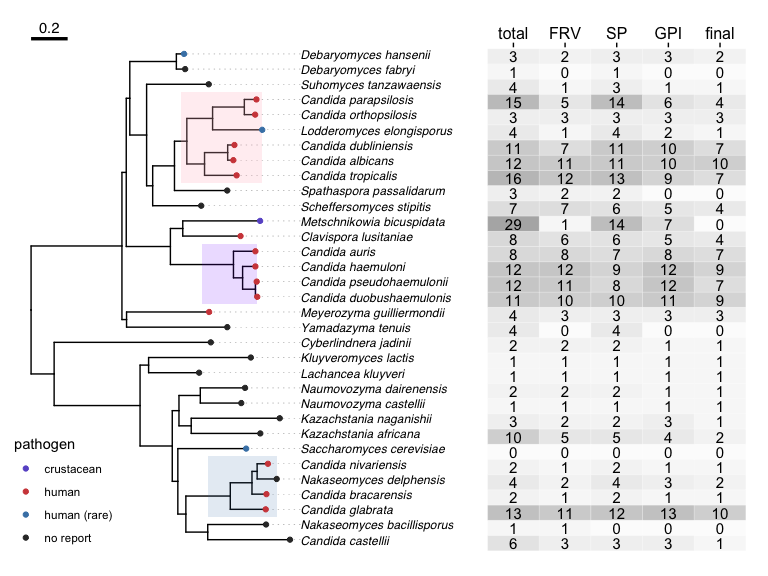

```r
p1 <- p + theme(axis.text.y = element_blank(), axis.ticks.y = element_blank())
plot_grid(p.tree, p1, rel_widths = c(3,2), scale = c(1, 0.95))
```

Summarize the % of Hil genes passing all three tests

| total | adhesin |
| --- | --- |
| 215 | 101 |

# Adhesin-related characteristics

## Serine/Threonine content

S/T sites are potential sites for O-glycosylation, which could increase the rididity of the stalk of the protein and allow the N-terminal domain to protrude out of the cell wall facing the exterior. More evidence for the importance of O-glycosylation in a serine/threonine-rich domain can be found [here](https://ec.asm.org/content/10/10/1317.long).

The goal here is to compare the S/T frequencies in the Hil proteins to the proteome average. First we need to calculate the S/T frequencies in the Hil proteins, either in the whole protein or excluding the PF11765 domain. This is done with a script in the `script` folder named `Hil-ST-freq.sh`

Read in the S/T frequencies

```r
ST <- list(
  full = read_tsv("../output/ST-freq/20220623-Hil-full-STfreq.out", col_types = "ciii"),
  noNTD = read_tsv("../output/ST-freq/20220623-Hil-noPF11765-STfreq.out", col_types = "ciii")
)
```

To determine the background frequency of Serine and Threonine in the proteome(s), I modified the `calc_aafreq_gz.py` script I wrote a long time ago for calculating the cystein and dibasic residues. I then copied four proteome fasta files, for *C. albicans*, *C. glabrata*, *S. cerevisiae* and *C. auris* and applied the script on them (using a wrapper script called `S-T-freq.sh`). Below I will look at both the proteome average and the distribution of S/T in individual proteins across the proteome.

```r
tmp.files <- list.files(path = "../output/ST-freq/", pattern = "*ST-freq.tsv.gz")
files <- file.path("../output/ST-freq", tmp.files)
names(files) <- gsub("-", " ", tmp.files) %>% word(1, 1)
bgST.freq <- files %>%
  map(~read_tsv(., col_types = cols())) %>%
  bind_rows(.id = "Species") %>%
  mutate(freqS = Ser/length, freqT = Thr/length,
         Ser = NULL, Thr = NULL,
         Species = paste0(str_sub(Species, 1, 1), ". ", str_sub(Species, 2))) %>%
  pivot_longer(cols = starts_with("freq"), names_to = "Residue", names_prefix = "freq", values_to = "frequency")
```

Is there any correlations between protein length and S/T frequency?

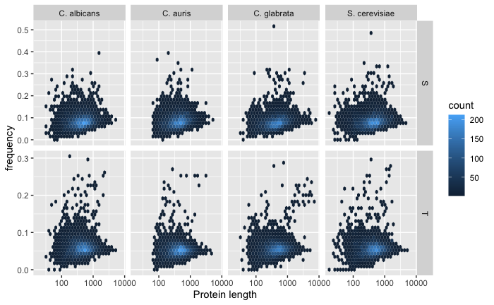

```r
bgST.freq %>%
  ggplot(aes(x = length, y = frequency)) +
  geom_hex() + facet_grid(Residue ~ Species, scales = "free_y") +
  scale_x_log10() + xlab("Protein length")
```

Doesn’t seem to be significant.

Now let’s combine the Hil protein S/T frequences as an extra “species” into the `bgST.freq`

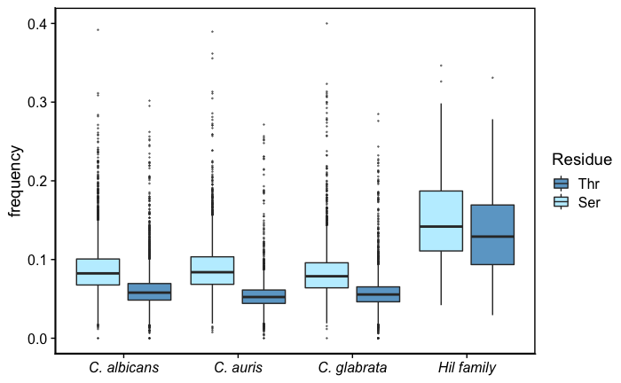

```r
tmp <- ST$full %>%
  mutate(Species = "Hil family", `S` = Ser/length, `T` = Thr/length) %>%
  pivot_longer(cols = c(`S`, `T`), names_to = "Residue", values_to = "frequency") %>%
  select(Species, ID, length, Residue, frequency) %>%
  bind_rows(filter(bgST.freq, Species != "S. cerevisiae")) %>%
  mutate(Residue = factor(Residue, levels = c("S", "T"), labels = c("Ser", "Thr")))
#tmp <- ST$noNTD %>%
#  mutate(Species = "Hil-PF11765", S = Ser/length, `T` = Thr/length) %>%
#  pivot_longer(cols = c(S, `T`), names_to = "Residue", values_to = "frequency") %>%
#  select(Species, ID, length, Residue, frequency) %>%
#  bind_rows(tmp)

p <- tmp %>%
  ggplot(aes(x = Species, y = frequency, fill = Residue)) +
  geom_boxplot(position = position_dodge(0.9), outlier.size = 0.2, outlier.alpha = 0.5) +
  scale_fill_manual(values = c("Thr" = "skyblue3", "Ser" = "lightblue1")) +
  scale_y_continuous(limits = c(0, 0.4), oob = scales::squish) +
  theme_cowplot() + panel_border(color = "black") +
  theme(axis.title.x = element_blank(), axis.text.x = element_text(face = 3))

p# + p1 + scale_color_manual(values = c("S" = alpha("gray20", 0.5), "T" = alpha("gray20", 0.5)))
ggsave("../output/img/20220623-Hil-ST-freq-compared-to-proteome.png", width = 5, height = 2.5)
```

```r
bgST.freq %>%
  group_by(Species, Residue) %>%
  summarize(mean = round(mean(frequency),3)) %>%
  pivot_wider(names_from = Residue, values_from = mean)
```

| Species | S | T |
| --- | --- | --- |
| C. albicans | 0.087 | 0.061 |
| C. auris | 0.088 | 0.054 |
| C. glabrata | 0.082 | 0.057 |
| S. cerevisiae | 0.086 | 0.058 |

## Tandem repeats

The non-NTD portion of the proteins evolve rapidly and many of them contain tandem repeats. Therefore, characterizing and visualizing the type, number and spatial distribution of the tandem repeats serve to highlight the differences in the non-NTD part of the proteins in this family.

To identify and group tandem repeats, I used [XSTREAM](https://amnewmanlab.stanford.edu/xstream) with the following parameters `java -Xmx1000m -Xms1000m -jar ~/sw/XSTREAM/xstream.jar $in -i.7 -I.7 -g3 -e2 -L15 -z -B -O -Asub.txt`. The parameters were chosen to identify degenerate tandem repeats that occur at least two times and the minimum length of a tandem repeat domain (=period x copy #) must be greater than 15 a.a. Please see `script/xstream.sh` for explanation of the parameters.

```r
tandem <- read_tsv("../output/xstream/XSTREAM_sub_i0.7_g3_m5_L15_chart.tsv",
                   col_types = "ciiifidcccd", comment = "#")
# now let's create a tibble for plotting, which would contain each instance of the tandem repeat on a separate row
tandem.div <- tandem %>%
  rowwise(name) %>%
  summarize(div = list(c(seq(from = start, to = end, by = period), end)), .groups = "drop") %>%
  unnest(div)
```

Examine the distribution of tandem repeat length as a fraction of the total protein minus the PF11765 domain

```r
# calculate repeat content
tr.len <- tandem %>%
  mutate(trLength = end - start + 1) %>%
  group_by(name) %>%
  summarize(trLen = sum(trLength), .groups = "drop") %>%
  right_join(select(blastInfo, name, seqLen = slen, species),
             by = "name") %>%
  mutate(trLen = ifelse(is.na(trLen), 0, trLen)) %>%
  full_join(pf11765.len, by = "name") %>%
  mutate(nonNTDLen = seqLen - dmLen, tr.perc = trLen/nonNTDLen) %>%
  full_join(select(name, frv.pred, sp.pred, gpi.pred), by = "name") %>%
  relocate(species, .after = last_col())
```

[output not shown]

Shorter proteins seem to have a lower content of tandem repeats as a percentrage of their non NTD portion of the protein.

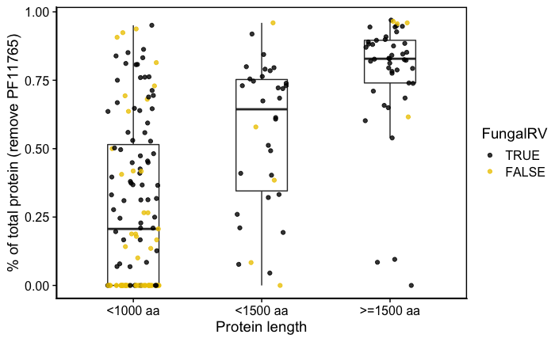

```r
tr.len %>%
  mutate(group = cut(seqLen, breaks = c(0,1000,1500,5000), labels = c("<1000 aa","<1500 aa",">=1500 aa"))) %>%
  ggplot(aes(x = group, y = tr.perc)) +
  geom_boxplot(outlier.shape = NA, width = 0.4) +
  geom_jitter(aes(color = frv.pred), width = 0.2, size = 1.5, alpha = 0.8) +
  scale_color_manual(name = "FungalRV", values = c("TRUE" = "black","FALSE" = "gold2")) +
  ylab("% of total protein (remove PF11765)") + xlab("Protein length") + #coord_flip() +
  theme_cowplot() + panel_border(color = "black")
ggsave("../output/img/20220624-tandem-repeat-proportion.png", width = 6, height = 4)
```

Test for correlations between sequence length and tandem repeat content

```r
# https://stackoverflow.com/questions/7549694/add-regression-line-equation-and-r2-on-graph
# # GET EQUATION AND R-SQUARED AS STRING
# # SOURCE: https://groups.google.com/forum/#!topic/ggplot2/1TgH-kG5XMA
# modified by Bin He 2021-06-28
lm_eq <- function(m){
    eq <- substitute(italic(y) == a + b %.% italic(x)*","~~italic(r)^2~"="~r2,
         list(a = format(unname(coef(m)[1]), digits = 4),
              b = format(unname(coef(m)[2]), digits = 4),
             r2 = format(summary(m)$r.squared, digits = 3)))
    as.character(as.expression(eq));
}

lm.obj <- lm(trLen ~ seqLen, tr.len)
```

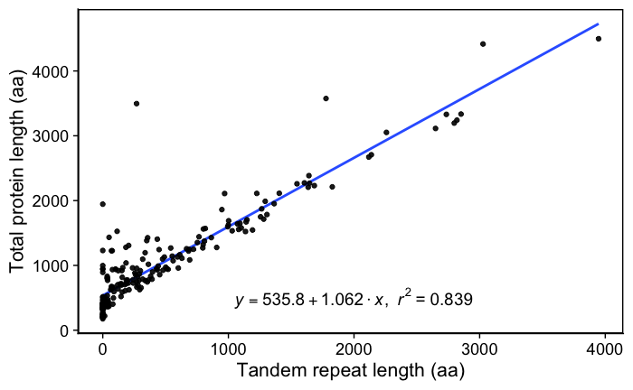

> Tandem repeat content is highly correlated to the total protein length, with an estimated slope of close to 1, suggesting that protein length evolution is strongly driven by the acquirement, expansion or contraction of tandem repeats.

## TANGO prediction of β-aggregation prone sequences

The amyloid-like $\beta$-aggregation prone sequences have the ability to mediate self-aggregation, which boosts the local concentration of the adhesin molecules on the cell-surface. Similar to the S/T frequency above, we would like to use the output from the prediction algorithm, TANGO, to visulize the distribution of such sequence motifs along the length of the XP_028889033 homolog sequences.

TANGO predictions and the subsequent extraction of $\beta$-aggregation prone sequences accomplished by `../script/parse_tango_output.R`

How many TANGO predicted β-aggregation sequences does each homolog has, either in the entire protein or in the non-NTD portion? To do so I’ll take advantage of the GRanges package to distinguish TANGO hits that are within or outside the PF11765 domain(s) for each protein. First, I need to convert the feature table into a GRanges object with the sequence names used as chromosome names and start and end as the IRanges start and end. Then I’ll convert the tango output also into a GRanges object in the same way, with the exception of keeping the median as the score field.

```r
# read in the summary results
tango <- read_tsv("../data/tango_summary_table.tsv.gz", col_types = "cciiidddicc") %>%
  left_join(blastInfo %>% select(id = pid, name), by = "id")

pf11765.gr <- pf11765 %>%
  select(seqname = name, start, end) %>%
  makeGRangesFromDataFrame(ignore.strand = TRUE)

tango.gr <- tango %>%
  select(seqname = name, start, end, score = median) %>%
  makeGRangesFromDataFrame(keep.extra.columns = TRUE, ignore.strand = TRUE)

# count the number of tango hits in the pf11765 domain
tango.gr.in <- subsetByOverlaps(tango.gr, pf11765.gr) %>%
  as_tibble() %>%
  mutate(InNTD = TRUE) %>%
  select(name = seqnames, start, end, InNTD)

tango <- tango %>%
  mutate(InNTD = FALSE) %>%
  rows_update(tango.gr.in, by = c("name", "start", "end"))

# remove intermediate objects
rm(list = c("tango.gr", "tango.gr.in", "pf11765.gr"))
```

Calculate summary statistics:

```r
tango.sum <- tango %>%
  group_by(name) %>%
  summarize(n.ntd = sum(InNTD), n.ntd.gt30 = sum(round(median,0) >= 30 & InNTD),
            n.rest = sum(!InNTD), n.rest.gt30 = sum(round(median,0) >= 30 & !InNTD)) %>%
  left_join(select(blastInfo, name, seqLen = slen), by = "name")

bind_rows(
  PF11765 = table(cut(tango.sum$n.ntd, breaks = c(0,1,3,5,10,Inf), right = FALSE)),
  `PF11765, >30` = table(cut(tango.sum$n.ntd.gt30, breaks = c(0,1,3,5,10,Inf), right = FALSE)),
  Rest = table(cut(tango.sum$n.rest, breaks = c(0,1,3,5,10,Inf), right = FALSE)),
  `Rest, >30` = table(cut(tango.sum$n.rest.gt30, breaks = c(0,1,3,5,10,Inf), right = FALSE)),
  .id = "group"
)
```

| group | [0,1) | [1,3) | [3,5) | [5,10) | [10,Inf) |
| --- | --- | --- | --- | --- | --- |
| PF11765 | 0 | 5 | 35 | 153 | 22 |
| PF11765, >30 | 2 | 60 | 105 | 46 | 2 |
| Rest | 45 | 50 | 28 | 34 | 58 |
| Rest, >30 | 57 | 70 | 39 | 23 | 26 |

> In sum, there are more TANGO predicted β-aggregation prone sequences in the PF11765 domain than in the rest of the proteins. This is likely a result of many short proteins not having an extensive number.

Examine the distribution of the number of TANGO hits and their spatial organization within each protein. One difference from my previous analysis is that I don’t exclude the hits in the PF11765 domain from the total count.

```r
# first count the number of out-of-NTD, median score >= 30 hits per sequence
motif.per.seq <- tango %>%
  group_by(name) %>%
  summarize(n.all = sum(round(median, 0) >= 30))

# next we will filter the tango dataset in order to recalculate the intervals
# this will result in 14 sequences to be dropped since they have 0 hits meeting
# the criteria. we will add them back by right_join() with the tibble above
motif.per.seq <- tango %>%
  # limit to hits with median score >= 30
  filter(round(median,0) >= 30) %>%
  group_by(name) %>%
  # recalculate the interval since we are now limiting the hits to >= 30
  mutate(interval = start - lag(end) - 1) %>%
  # summarize the results at a sequence level
  summarize(n.type = length(unique(seq)),
            n.all = n(),
            medScore = round(mean(median),1),
            IVT = round(mean(ivt),2),
            avg.intv = round(mean(interval, na.rm = T),1),
            IQR.intv = round(IQR(interval, na.rm = T)/1.349 ,1),
            # median absolute deviation is a robust measure of the scale parameter
            # https://www.rdocumentation.org/packages/stats/versions/3.6.2/topics/mad
            mad.intv = round(mad(interval, na.rm = T),1),
            seqs = paste(unique(seq), collapse = ","),
            .groups = "drop_last") %>%
  right_join(motif.per.seq, by = c("name", "n.all")) %>%
  arrange(desc(n.all), desc(mad.intv))
DT::datatable(motif.per.seq)
```

|  | name | n.type | n.all | medScore | IVT | avg.intv | IQR.intv | mad.intv | seqs |
| --- | --- | --- | --- | --- | --- | --- | --- | --- | --- |
| 1 | XP_025344407.1_Candida_haemuloni | 15 | 70 | 78.7 | 0.78 | 56.3 | 0 | 0 | ALVGIAQAIVSL,AFYIRYGDFTYALGYWVT,TVGVLGIGYI,SAYMVF,NVIVLST,WLLSAFYLSAVWALTIT,VYYSIVN,LTLSFLLGIF,GVVLITT,GVIVVTT,GVVIVTT,GIVIVTT,VVIVIT,GVIIVTT,FAFFAA |
| 2 | XP_024713121.1_Candida_pseudohaemulonii | 11 | 62 | 81.9 | 0.82 | 46.2 | 0.7 | 1.5 | LAASVSIVLGLI,ALLLLLI,TLTLSFFLGIF,GIVVVTT,GVVVVTT,GVVIVTT,GVVIVT,GVIIVTT,TGVVIVTT,VAVVTT,LAFFAI |
| 3 | XP_025334498.1_Candida_duobushaemulonis | 14 | 54 | 81.3 | 0.82 | 46.6 | 0.7 | 0 | TLTLSFFLGIF,GLVVVTT,GVVVVTT,GVVIVTT,GVVIVT,GVVIVST,GVVVVTA,GVIIVTT,GLVIVTT,GIVIVTT,GVVVITT,TGVVIVTT,VAVVTT,LAFFAI |
| 4 | XP_028889033.1_Candida_auris | 15 | 52 | 83.6 | 0.81 | 49.5 | 1.9 | 0 | GWLLLAFYLSATWALTIT,GVYYSIV,TLTLSFFLGLF,GVVIVTT,GVVVVTT,GIVVVTT,GVIIVTT,GVVIVTA,GIIVVTT,GVIVVTT,SGVVVVTT,GVIIVTA,GLVIVTT,AVIVTT,TTVTAAVI |
| 5 | XP_025344416.1_Candida_haemuloni | 10 | 45 | 80 | 0.8 | 53.1 | 9.6 | 7.4 | GWLATALYLSAVWALTIT,GVLTLSFFLGVF,GVVIVTT,GVIIVTT,GVVIVTA,GVVVVTT,GLVIVTT,SGVVIITT,VVVVGT,FAFFAM |
| 6 | XP_024712318.1_Candida_pseudohaemulonii | 25 | 43 | 67.6 | 0.73 | 63.1 | 2 | 1.5 | GFMWFGI,VLTLSFFGGLF,GIVVVTT,GVVVISC,VVIVT,VVTLTIC,LGLLTLALYLSAVWGLTI,VLYLA,GVLKIVFFE,GVVLVTT,GIVVV,GVVVV,GVVIVT,GVVIVTA,GIIVV,GVVVVTA,GVVIV,GVIIVT,GIVIVT,GIIIVT,GVVIIAT,GVVVVTT,GIIIVTT,GVIIVTA,GVVVVT |
| 7 | XP_025343300.1_Candida_haemuloni | 18 | 37 | 78.5 | 0.8 | 52.5 | 3 | 0.7 | FMWFGISSF,TVLILTFFAGLF,GVVIITT,GVIIVTT,GIVVVT,GVIIVTS,GVVIVTT,GIVVV,VVIVIT,GVVVVST,GVVIVTS,GIIIVTT,GIVIVTT,GIVVVTT,TVSGIIVVTT,ISGIVIVTT,CIVIVTT,LAVLV |
| 8 | XP_001523105.1_Lodderomyces_elongisporus | 35 | 36 | 62.9 | 0.52 | 91.8 | 85.6 | 66.7 | FWILLLLV,VYWSIV,GLIYLY,ALLVFGALQSIV,IVVVVTT,TATAVVIVTT,YFTSYTTVLT,TATAVII,LALVI,VYVVKVVNNEFFTIF,TLVLVINVI,ISLQTLFTTWY,LVTVF,SSLLTLALII,FTTIFYM,TLLLAI,TKIVEVLVTM,WITIF,STIYTSLYIA,TLILVI,IVMLTS,TLITTWF,… |
| 9 | XP_025335682.1_Candida_duobushaemulonis | 12 | 28 | 74.7 | 0.75 | 61.4 | 6.7 | 3 | GWLAALSLYVATAMALTIS,VYYSIV,TLTLSFFLGVF,GVVIVTT,GVVVVTT,GIVIVTT,GVVIVAT,GVVIVST,GVVIVGT,VAVVTT,LVIVTT,FAFFAM |
| 10 | XP_024711351.1_Candida_pseudohaemulonii | 8 | 27 | 79.4 | 0.77 | 50.7 | 3 | 3 | YSFSWLAVALYLATALGLTIT,LVSVVGL,LLTLSFFLGLF,GVVIVTT,TGVVIVTT,ITTSGVVIVTT,TIVVLT,LGLFVL |

[output cut: 205 more lines]

```r
# add extra information for plotting below
motif.per.seq <- motif.per.seq %>%
  left_join(select(blastInfo, species, name), by = "name") %>%
  mutate(reg.spaced = ifelse(n.all > 3 & mad.intv < 5, TRUE, FALSE),
         mad.intv = ifelse(n.all > 2, mad.intv, NA),
         species = ordered(species, levels = get_taxa_name(p.tree)))
         #species = reorder(species, desc(species)),
         #species_id = NULL)
```

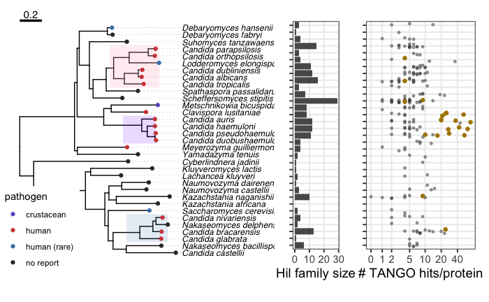

# Feature map for homologs

The goal is to produce a cartoon-like plot for each homolog outlining their main features, such as the locations of the PFam domains (mainly the Hyp_reg_CWP), locations of the signal peptide and GPI-anchor, distribution of TANGO sequences. Note that all these features can be represented as a range with associated metadata. So the first step is to collect the coordinates of the features

## Organize and combine the tandem repeats features

```r
tr <- tandem %>%
  left_join(select(repeats, type, copyMean), by = c("type" = "type")) %>%
  mutate(type = "Tandem Repeats") %>%
  select(name, type, start, end)
```

```r
# GPI-anchor
# use pred.gpi
# feature set
# structure: id  feature  start  end
feature <- bind_rows(
  pfam %>% select(name = seq_id, type = hmm_name, start = envelope_start, end = envelope_end) %>%
    filter(type == "Hyphal_reg_CWP"),
  # extend the signal peptide segment by 10 amino acids to make it more visible
  signalp5 %>% mutate(type = "Signal Peptide", end = end + 10) %>% select(name = id, type, start = start, end),
  # extend the GPI-anchor C-terminus segment by 20 amino acids to make it more visible
  pred.gpi %>% filter(is.gpi) %>% mutate(type = "GPI-anchor", start = cleavePos-10) %>%
    select(name, type, start, end = length),
  tr
)

# in order to plot properties of the sequences in an order that is consistent with the sequences' position in the gene tree
genetreeOrder <- scan("data/reorder_by_gene_tree.txt", what = "character")
seqLen$name <- ordered(seqLen$name, levels = rev(genetreeOrder))

feature <- feature %>%
  mutate(name = ordered(name, levels = rev(genetreeOrder)),
         type = ordered(type, levels = c("entire protein", "Hyphal_reg_CWP", "Signal Peptide", "GPI-anchor", "Tandem Repeats")))
feature.colors <- c(Hyphal_reg_CWP = "#3d85c6", "Signal Peptide" = "#cc0000", "GPI-anchor" = "#6a3d9a", "Tandem Repeats" = "#af8400bb")
```

## Plot domain organization

```r
# plot
p0 <- ggplot(seqLen, aes(x = name, y = start, xend = name, yend = end)) +
  #geom_segment(color = "black", size = 2.1) +
  geom_segment(color = "gray80", size = 2)
p1 <- geom_segment(data = feature, aes(color = type), size = 2)
p2 <- geom_segment(data = tandem.div, aes(x = name, xend = name, y = div, yend = div + 1.5), size = 2, color = "white")
p3 <- p0 + p1 + coord_flip() + theme_classic() +
  scale_color_manual(values = feature.colors) +
  scale_y_continuous(expand = expansion(mult = c(0.02, 0.02))) +
  theme(axis.text.y = element_text(size = 4), axis.title.y = element_blank(),
        axis.line.y = element_blank(), axis.ticks.y = element_blank(),
        axis.line.x = element_blank(),# axis.ticks.x = element_blank(),
        legend.position = c(0.75, 0.35),
        legend.text = element_text(size = 12), legend.title = element_text(size = 14),
        plot.title = element_text(hjust = 0.5),
        panel.background = element_rect(fill = alpha("lightblue",0.1))) +
  labs(y = "Position in sequence", x = "Sequences", color = "FEATURES")
#plot_grid(p.gtree, p3, ncol = 2, align = 'v', rel_widths = c(1,2), scale = c(1.01,1))
ggsave("output/img/20210625-domain-tandem-repeats.png", width = 6, height = 7.5)
```

## Separate TR types

```r
DT::datatable(
  tandem %>%
    dplyr::rename(seqL = seqLength, err = consensus_error, seq = consensus_nogap) %>%
    select(-seqAlign, -type, -consensus_gap, -seq, seq) %>%
    arrange(desc(name)),
  fillContainer = FALSE, options = list(pageLength = 10)
)
```

Repeat the above analysis but distinguishing between all different TR types

```r
tr1 <- tandem %>%
  left_join(select(repeats, type, copyMean), by = c("type" = "type")) %>%
  mutate(type = paste0("TR-", type),
         tip = paste0(consensus_nogap,
                      "\ntype: ", type,
                      "\nperiod: ", period,
                      "\ncopyN: ", copyMean),
         name = ordered(name, levels = rev(genetreeOrder))) %>%
  select(name, type, start, end, tip)
```

```r
require(RColorBrewer)
tr.th <- 100 # arbitrary threshold for distinguishing "short" from "long" TRs
tr.col <- character(nrow(repeats)) # create a color vector
short.rp <- which(repeats$length < tr.th) # identify the short repeats indices
long.rp <- setdiff(1:nrow(repeats), short.rp) # the long repeats indices
set.seed(123) # for reproducibly shuffling the order before assigning the colors
short.rp <- sample(short.rp) # shuffle the indices for short tandem repeats
tr.col[short.rp] <- colorRampPalette(brewer.pal(12, "Paired")[seq(3,11,by=2)])(length(short.rp)) # assign the short repeats a lower contrast color
set.seed(231) # for reproducibly shuffling the order before assigning the colors
long.rp <- sample(long.rp)
tr.col[long.rp] <- colorRampPalette(brewer.pal(12, "Paired")[seq(4,12,by=2)])(length(long.rp)) # assign the long repeats a higher contrast color
# -- desaturate the colors --
# https://stackoverflow.com/questions/26314701/r-reducing-colour-saturation-of-a-colour-palette
library(colorspace)   ## hsv colorspace manipulations

## Function for desaturating colors by specified proportion
desat <- function(cols, sat=0.5) {
    X <- diag(c(1, sat, 1)) %*% rgb2hsv(col2rgb(cols))
    hsv(X[1,], X[2,], X[3,])
}

tr.col <- desat(tr.col, sat = 0.8)
# -- finish --
tr.col <- paste0(tr.col, "CC") # add 20% transparency to the TR features
names(tr.col) <- paste0("TR-", repeats$type) # name the colors by the TR types
repeats$color <- tr.col
```

Combine domains, SP and GPI-anchor with TR features.

```r
# combine sequence features with tandem repeats
feature1 <- bind_rows(filter(feature, type != "Tandem Repeats"), tr1) %>%
  mutate(type = ordered(type, levels = c("Hyphal_reg_CWP", "SignalP", "GPI-anchor", unique(tr1$type))))
feature.col1 <- c(feature.colors[1:3], tr.col) # remove the singel "Tandem Repeats" type
write_tsv(feature1, file = "output/misc/R-feature-table.tsv", col_names = TRUE)
```

```r
# plot
p0 <- ggplot(seqLen, aes(x = name, y = start, xend = name, yend = end)) +
  #geom_segment(color = "black", size = 2.1) +
  geom_segment(color = "gray80", size = 2)
p1 <- geom_segment(data = feature1, aes(color = type, text = tip), size = 2)
p2 <- geom_segment(data = tandem.div, aes(x = name, xend = name, y = div, yend = div + 1.5), size = 2, color = "white")
p3 <- p0 + p1 + coord_flip() + theme_classic() +
  scale_color_manual(values = feature.col1) +
  scale_y_continuous(expand = expansion(mult = c(0.02, 0.02))) +
  theme(axis.text.y = element_text(size = 4), axis.title.y = element_blank(),
        axis.line.y = element_blank(), axis.ticks.y = element_blank(),
        axis.line.x = element_blank(),# axis.ticks.x = element_blank(),
        legend.position = "none", plot.title = element_text(hjust = 0.5),
        panel.background = element_rect(fill = alpha("lightblue",0.1))) +
  labs(y = "Position in sequence", x = "Sequences", color = "FEATURES")
# plot_grid(p.gtree, p3 + p2, ncol = 2, align = 'v', rel_widths = c(1,2), scale = c(1.01,1))
ggsave("output/img/20210626-domain-tandem-repeats-distinct-color.png", width = 5, height = 7.5)
```

```r
# plot
#require(plotly)
ggplotly(p3, tooltip = "text", width = 900, height = 900)
```

## Tango predicted β-aggregation sequences

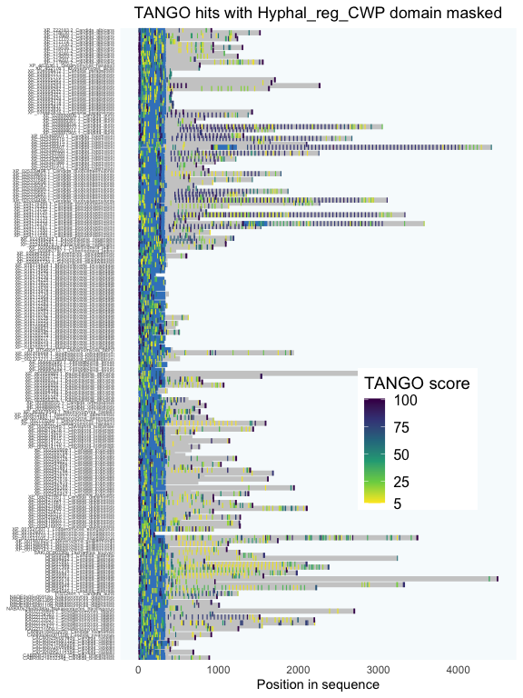

```r
# reorder the sequences for plotting
#tango$name <- ordered(tango$name, levels = rev(genetreeOrder))
seqLen <- blastInfo %>% mutate(start = 1) %>% select(name, start, end = slen)
# plot
p1 <- ggplot(seqLen, aes(x = name, y = start, xend = name, yend = end)) + geom_segment(color = "gray80", size = 2)
p2 <- geom_segment(data = pf11765, aes(x = name, y = start+1, xend = name, yend = end), size = 2, color = "#3d84c6")
p3 <- geom_segment(data = tango, aes(x = name, xend = name,  y = ifelse(start-4 >= 0, start-4, 0), yend = end + 4, color = median), size = 2)
p4 <- p1 + p2 + p3 + coord_flip() + theme_classic() +
  scale_color_viridis_c(limits = c(5,101), breaks = c(5,seq(25,100,25)), direction = -1) +
  theme(axis.text.y = element_text(size = 4), axis.title.y = element_blank(),
        axis.line.y = element_blank(), axis.ticks.y = element_blank(),
        axis.line.x = element_blank(), axis.ticks.x = element_blank(),
        plot.title = element_text(hjust = 0.5),
        legend.position = c(0.75,0.35),
        legend.title = element_text(size = 14),
        legend.text = element_text(size = 12),
        panel.background = element_rect(fill = alpha("lightblue",0.1))) +
  ylim(-2, 4500) + labs(y = "Position in sequence", x = "Sequences", color = "TANGO score") +
  ggtitle("TANGO hits with Hyphal_reg_CWP domain masked")
p4
```

```r
##plot_grid(p.gtree, p4, ncol = 2, align = 'v', rel_widths = c(1,2.5), scale = c(1.01,1))
#ggsave("output/img/20210110-tango-score-segment.png", width = 6, height = 7.5)
```

# Similarity and divergence

## Length distribution

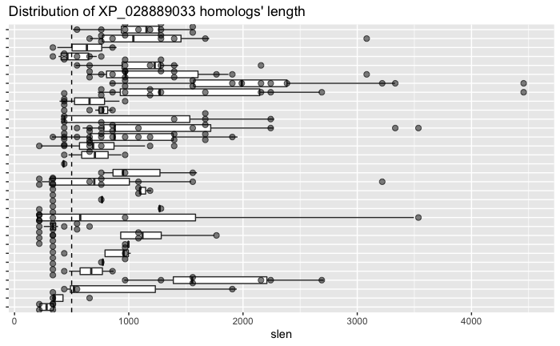

**Discussion**